# Proyecto

```python
import empiricaldist
import janitor
import matplotlib.pyplot as plt
import numpy as np
import pandas as pd
import scipy.stats
import seaborn as sns
import sklearn.metrics
import statsmodels.api as sm
import statsmodels.formula.api as smf
import statsmodels.stats as ss
import session_info
```

**DESCRIPCIÓN:** Se recolectan datos mediante los siguientes sensores: (DHT 22:Temperatura y humedad y MQ135: Calidad de aire), los cuales se envian cada minuto a un base de datos en tiempo real, para su analisis

Los datos obtenidos son de un vivienda ubicada en Juliaca-Puno_Perú a 3.824 m.s.n.m, dentro de una habitación (dormitorio), donde el clina es especialmete variable, lo que se pretende demostrar

#### Preguntas

1. ¿Cuales son lo valores maximos y minimos de la temperatura, humedad y calidad de aire?
2. ¿A cuanto baja la temperatura por las noches?
3. ¿Cuales son las horas con las temperaturas mas altas y mas bajas?
4. ¿Cuales son las horas que se presentan la humedad mas alta y baja?
5. ¿Cómo puedo visualizar la distribución de una variables?
6. ¿La calidad de aire es adecuada en la vivienda?
7. ¿Que variables se correlacionan?
8. ¿Es posible crear grupos?

# 1. Adquisisción y limpieza de datos

```python
df=pd.read_json('smarthome-5f73f-dataSensorDormitorio-exportv4.json')
dataframepre=df.T
dataframepre.head()
```

|  | air | humidity | temperature | timestamp |
| --- | --- | --- | --- | --- |
| -NnWi0cfh7JL4zERf4-B | 57.0 | 60.6 | 20.5 | 1.704594e+09 |
| -NnWiFSGx3FQP2RJOK1f | 159.0 | 65.1 | 20.5 | 1.704594e+09 |
| -NnWiUJxNXL_9tjXc-Tu | 168.0 | 55.4 | 20.6 | 1.704594e+09 |
| -NnWii_WfPRCkdzoqwGK | 175.0 | 54.7 | 20.4 | 1.704594e+09 |
| -NnWj6uOjSowuIghE9CV | 91.0 | 56.9 | 20.2 | 1.704594e+09 |

```python
#Tipo de dato de las variables
dataframepre.dtypes
```

```
air            float64
humidity       float64
temperature    float64
timestamp      float64
dtype: object
```

```python
#Cantidad de observaciones y cantidad de variables
dataframepre.shape
```

```
(5384, 4)
```

```python
#Verificamos si existen valores nulos
dataframepre.isnull().any()
```

```
air            False
humidity       False
temperature    False
timestamp      False
dtype: bool
```

Como los datos se obtubieron mediante una plataforma basada en sistemas embebidos y sensores los cuales envian los datos a una base de datos en timepo real (Firebase), en los datos no se encuentran valores nulos y los datos se evian formateados en JSON.

```python
#Cambiamos el timestamp por formato de dia/mes/año
import pytz
import dateutil.tz
from datetime import datetime
datefull=pd.to_datetime(dataframepre['timestamp'], unit='s',utc=True).map(lambda x: x.tz_convert('America/Lima'))
datefull
```

```
-NnWi0cfh7JL4zERf4-B   2024-01-06 21:19:46-05:00
-NnWiFSGx3FQP2RJOK1f   2024-01-06 21:20:48-05:00
-NnWiUJxNXL_9tjXc-Tu   2024-01-06 21:21:49-05:00
-NnWii_WfPRCkdzoqwGK   2024-01-06 21:22:50-05:00
-NnWj6uOjSowuIghE9CV   2024-01-06 21:24:34-05:00
                                  ...
-Nnq78q_-ouminZ10AU9   2024-01-10 20:26:19-05:00
-Nnq7NgUi_-Hrb0BV-4d   2024-01-10 20:27:22-05:00
-Nnq7bZU9ap-Eihf4shf   2024-01-10 20:28:23-05:00
-Nnq7qkDW7wddNu0j-Yd   2024-01-10 20:29:24-05:00
-Nnq8JqORxpduv4TE2Aj   2024-01-10 20:31:27-05:00
Name: timestamp, Length: 5384, dtype: datetime64[ns, America/Lima]
```

```python
date=datefull.dt.strftime('%d/%m/%Y')
date
```

```
-NnWi0cfh7JL4zERf4-B    06/01/2024
-NnWiFSGx3FQP2RJOK1f    06/01/2024
-NnWiUJxNXL_9tjXc-Tu    06/01/2024
-NnWii_WfPRCkdzoqwGK    06/01/2024
-NnWj6uOjSowuIghE9CV    06/01/2024
                           ...
-Nnq78q_-ouminZ10AU9    10/01/2024
-Nnq7NgUi_-Hrb0BV-4d    10/01/2024
-Nnq7bZU9ap-Eihf4shf    10/01/2024
-Nnq7qkDW7wddNu0j-Yd    10/01/2024
-Nnq8JqORxpduv4TE2Aj    10/01/2024
Name: timestamp, Length: 5384, dtype: object
```

```python
#Reemplazamos la coolumna de timestamp por date
dataframepre.timestamp=date
dataframepre.head()
```

|  | air | humidity | temperature | timestamp |
| --- | --- | --- | --- | --- |
| -NnWi0cfh7JL4zERf4-B | 57.0 | 60.6 | 20.5 | 06/01/2024 |
| -NnWiFSGx3FQP2RJOK1f | 159.0 | 65.1 | 20.5 | 06/01/2024 |
| -NnWiUJxNXL_9tjXc-Tu | 168.0 | 55.4 | 20.6 | 06/01/2024 |
| -NnWii_WfPRCkdzoqwGK | 175.0 | 54.7 | 20.4 | 06/01/2024 |
| -NnWj6uOjSowuIghE9CV | 91.0 | 56.9 | 20.2 | 06/01/2024 |

```python
## Realizamos un rename de la columna timestamp
dataframe=dataframepre.rename(columns={'timestamp':'date'})
dataframe.head()
```

|  | air | humidity | temperature | date |
| --- | --- | --- | --- | --- |
| -NnWi0cfh7JL4zERf4-B | 57.0 | 60.6 | 20.5 | 06/01/2024 |
| -NnWiFSGx3FQP2RJOK1f | 159.0 | 65.1 | 20.5 | 06/01/2024 |
| -NnWiUJxNXL_9tjXc-Tu | 168.0 | 55.4 | 20.6 | 06/01/2024 |
| -NnWii_WfPRCkdzoqwGK | 175.0 | 54.7 | 20.4 | 06/01/2024 |
| -NnWj6uOjSowuIghE9CV | 91.0 | 56.9 | 20.2 | 06/01/2024 |

```python
#Agregamoscolumnas de mes,dia,hora para futuros analisis
month=datefull.dt.strftime('%m')
day=datefull.dt.strftime('%d')
hour=datefull.dt.strftime('%H') #formato 24 horas
dataframe['month']=month
dataframe['day']=day
dataframe['hour']=hour
dataframe.head()
```

|  | air | humidity | temperature | date | month | day | hour |
| --- | --- | --- | --- | --- | --- | --- | --- |
| -NnWi0cfh7JL4zERf4-B | 57.0 | 60.6 | 20.5 | 06/01/2024 | 01 | 06 | 21 |
| -NnWiFSGx3FQP2RJOK1f | 159.0 | 65.1 | 20.5 | 06/01/2024 | 01 | 06 | 21 |
| -NnWiUJxNXL_9tjXc-Tu | 168.0 | 55.4 | 20.6 | 06/01/2024 | 01 | 06 | 21 |
| -NnWii_WfPRCkdzoqwGK | 175.0 | 54.7 | 20.4 | 06/01/2024 | 01 | 06 | 21 |
| -NnWj6uOjSowuIghE9CV | 91.0 | 56.9 | 20.2 | 06/01/2024 | 01 | 06 | 21 |

# 2. Análsisis univariado

## Tabla de frecuencias

```python
#Tabla de frecuencias por dia
fi=dataframe.date.value_counts()
hi=dataframe.date.value_counts(normalize=True)
hip=hi*100
tabla=pd.DataFrame({
    'fi': fi.values,
    'hi': hi.values,
    'hi%': hip.map('{:.2f}%'.format)
})
total=dataframe.shape[0]
tabla.loc['Total'] = [total,hi.values.sum(),str(round(hip.sum(),2))+'%']
print(tabla)
```

```
              fi        hi     hi%
date
07/01/2024  1376  0.255572  25.56%
09/01/2024  1363  0.253158  25.32%
08/01/2024  1349  0.250557  25.06%
10/01/2024  1158  0.215082  21.51%
06/01/2024   138  0.025632   2.56%
Total       5384  1.000000  100.0%
```

```python
#Tabla de frecuencias por Calidad de aire
fi=dataframe.air.value_counts()
hi=dataframe.air.value_counts(normalize=True)
hip=hi*100
tabla=pd.DataFrame({
    'fi': fi.values,
    'hi': hi.values,
    'hi%': hip.map('{:.2f}%'.format)
})
total=dataframe.shape[0]
tabla.loc['Total'] = [total,hi.values.sum(),str(round(hip.sum(),2))+'%']
print(tabla)
```

```
         fi        hi     hi%
air
393.0   140  0.026003   2.60%
387.0   133  0.024703   2.47%
401.0   125  0.023217   2.32%
405.0   119  0.022103   2.21%
392.0   117  0.021731   2.17%
...     ...       ...     ...
329.0     1  0.000186   0.02%
327.0     1  0.000186   0.02%
342.0     1  0.000186   0.02%
352.0     1  0.000186   0.02%
Total  5384  1.000000  100.0%

[190 rows x 3 columns]
```

```python
#Tabla de frecuencias por temperatura
fi=dataframe.temperature.value_counts()
hi=dataframe.temperature.value_counts(normalize=True)
hip=hi*100
tabla=pd.DataFrame({
    'fi': fi.values,
    'hi': hi.values,
    'hi%': hip.map('{:.2f}%'.format)
})
total=dataframe.shape[0]
tabla.loc['Total'] = [total,hi.values.sum(),str(round(hip.sum(),2))+'%']
print(tabla)
```

```
               fi        hi     hi%
temperature
23.6          108  0.020059   2.01%
14.3          107  0.019874   1.99%
23.7           96  0.017831   1.78%
14.5           93  0.017273   1.73%
24.4           93  0.017273   1.73%
...           ...       ...     ...
36.0            1  0.000186   0.02%
36.6            1  0.000186   0.02%
36.2            1  0.000186   0.02%
37.6            1  0.000186   0.02%
Total        5384  1.000000  100.0%

[255 rows x 3 columns]
```

```python
#Tabla de frecuencias por Humedad
fi=dataframe.humidity.value_counts()
hi=dataframe.humidity.value_counts(normalize=True)
hip=hi*100
tabla=pd.DataFrame({
    'fi': fi.values,
    'hi': hi.values,
    'hi%': hip.map('{:.2f}%'.format)
})
total=dataframe.shape[0]
tabla.loc['Total'] = [total,hi.values.sum(),str(round(hip.sum(),2))+'%']
print(tabla)
```

```
            fi        hi     hi%
humidity
92.6       129  0.023960   2.40%
92.5        80  0.014859   1.49%
93.2        61  0.011330   1.13%
92.7        60  0.011144   1.11%
93.1        57  0.010587   1.06%
...        ...       ...     ...
86.1         1  0.000186   0.02%
84.3         1  0.000186   0.02%
73.8         1  0.000186   0.02%
62.2         1  0.000186   0.02%
Total     5384  1.000000  100.0%

[717 rows x 3 columns]
```

## Visualización de conteos

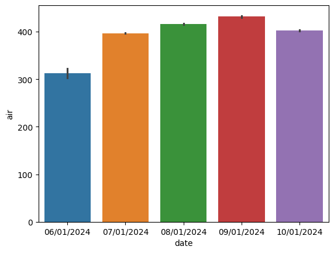

```python
#Cantidad de datos obtenidos por dia
sns.barplot(
    x = "date",
    y = "air",
    hue='date',
    data = dataframe
)
```

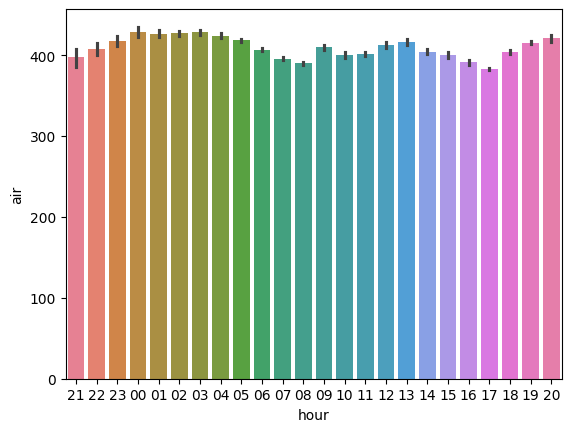

```python
#Calidad de aire por horas
sns.barplot(
    x = "hour",
    y = "air",
    data = dataframe,
    hue='hour',
)
```

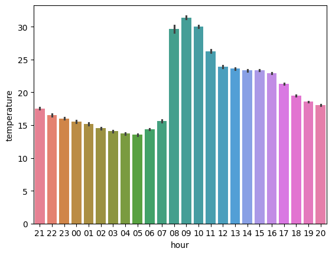

```python
#Temperatura por horas
sns.barplot(
    x = "hour",
    y = "temperature",
    data = dataframe,
    hue='hour',
)
```

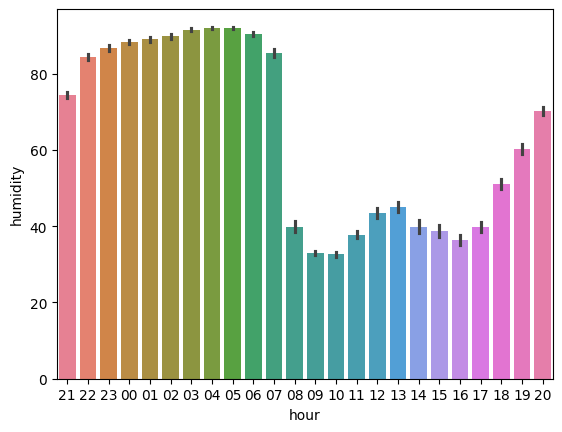

```python
#Humedad por horas
sns.barplot(
    x = "hour",
    y = "humidity",
    data = dataframe,
    hue='hour',
)
```

No se realizaron graficos de proporciones, porque los datos tomados de los 3 sensores son en la misma cantidad

# Estadistica descriptiva

```python
#Media o promedio
print(f'Calidad de aire {round(dataframe.air.mean(),2)}')
print(f'Temperatura {round(dataframe.temperature.mean(),2)}')
print(f'Humedad {round(dataframe.humidity.mean(),2)}')
```

```
Calidad de aire 409.41
Temperatura 19.94
Humedad 63.84
```

```python
#Mediana
print(round(dataframe.median(numeric_only=True),2))
```

```
air            406.0
humidity        65.5
temperature     18.5
dtype: float64
```

```python
#Moda
print(round(dataframe.mode(numeric_only=True),2))
```

```
     air  humidity  temperature
0  393.0      92.6         23.6
```

### Medidas de dispersión

```python
#Maximo
dataframe.max(numeric_only=True)
```

```
air            497.0
humidity        94.7
temperature     37.6
dtype: float64
```

```python
#Minimo
dataframe.min(numeric_only=True)
```

```
air            57.0
humidity       17.3
temperature    11.6
dtype: float64
```

```python
#rango
dataframe.max(numeric_only=True)-dataframe.min(numeric_only=True)
```

```
air            440.0
humidity        77.4
temperature     26.0
dtype: float64
```

```python
#desviación estándar: cuantifica la variación o la dispersión de un conjunto de datos numéricos respecto a la media
dataframe.std(numeric_only=True)
```

```
air            34.186367
humidity       24.918424
temperature     5.631742
dtype: float64
```

### Rango intercuartileo

```python
#Q1, Q2, Q3 y rango intercuatileo-IQR (Q3-Q1)->medida de la dispersión basado en la mediana
#El IQR permite determinar los valores atipicos que se encuentran 1.5 veces esa distancia
#(atípico leve) o a 3 veces esa distancia (atípico extremo).  test de Tukey
dataframe.quantile([.25,.50,.75],numeric_only=True).T.rename_axis('variable').assign(
    IQR= lambda df: df[0.75] - df[0.25]
)
#(38*1.5)+406=463
#(38*1.5)-406=349
```

| variable | 0.25 | 0.5 | 0.75 | IQR |
| --- | --- | --- | --- | --- |
| air | 389.0 | 406.0 | 432.0 | 43.0 |
| humidity | 40.8 | 65.5 | 90.5 | 49.7 |
| temperature | 15.1 | 18.5 | 23.7 | 8.6 |

## Visualización de la distribución de las variables

### Histograma de calidad de aire

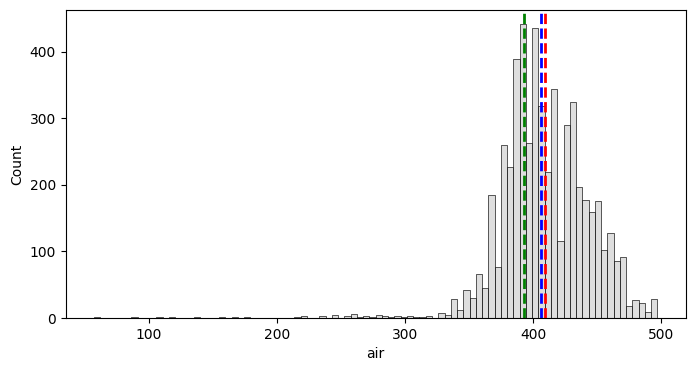

```python
#Histograma: Rojo media, Azul Mediana y Verde Moda
plt.figure(figsize=(8,4))
sns.histplot(
    data=dataframe,
    color='lightgray',
    x='air',
)
plt.axvline(
    x=dataframe.air.mean(),
    color='red',
    linestyle='dashed',
    linewidth=2
)
plt.axvline(
    x=dataframe.air.median(),
    color='blue',
    linestyle='dashed',
    linewidth=2
)
plt.axvline(
    x=dataframe.air.mode()[0],
    color='green',
    linestyle='dashed',
    linewidth=2
)
```

### Histograma de Temperatura

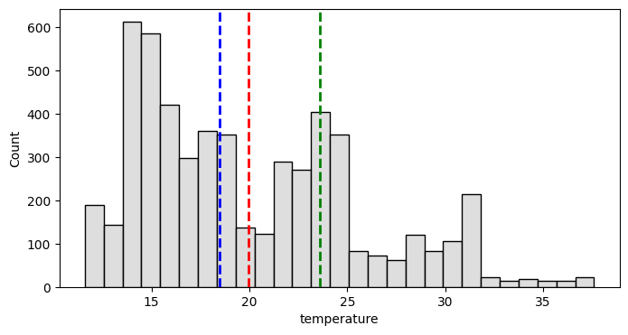

```python
#Histograma: Rojo media, Azul Mediana y Verde Moda
plt.figure(figsize=(8,4))
sns.histplot(
    data=dataframe,
    color='lightgray',
    x='temperature',
)
plt.axvline(
    x=dataframe.temperature.mean(),
    color='red',
    linestyle='dashed',
    linewidth=2
)
plt.axvline(
    x=dataframe.temperature.median(),
    color='blue',
    linestyle='dashed',
    linewidth=2
)
plt.axvline(
    x=dataframe.temperature.mode()[0],
    color='green',
    linestyle='dashed',
    linewidth=2
)
```

### Histograma de Humedad

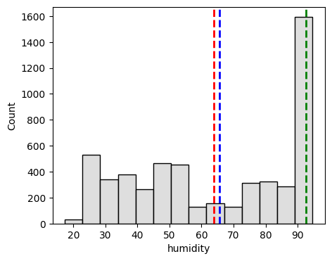

```python
#Histograma: Rojo media, Azul Mediana y Verde Moda
plt.figure(figsize=(5,4))
sns.histplot(
    data=dataframe,
    color='lightgray',
    x='humidity',
)
plt.axvline(
    x=dataframe.humidity.mean(),
    color='red',
    linestyle='dashed',
    linewidth=2
)
plt.axvline(
    x=dataframe.humidity.median(),
    color='blue',
    linestyle='dashed',
    linewidth=2
)
plt.axvline(
    x=dataframe.humidity.mode()[0],
    color='green',
    linestyle='dashed',
    linewidth=2
)
```

### Digrama de cajas/boxplot

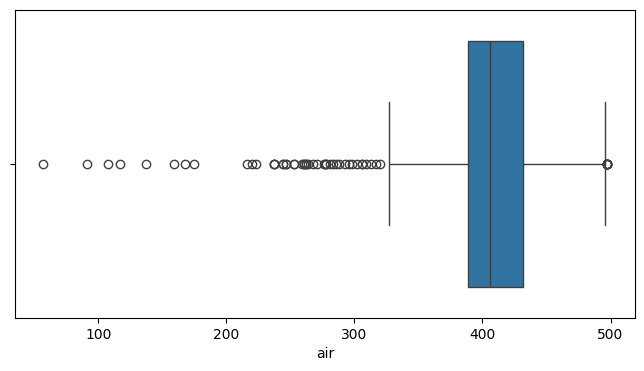

```python
#Caja de la variable Calidad de aire, considerando todo el dataset
plt.figure(figsize=(8,4))
sns.boxplot (
    data=dataframe,
    x='air',
)
#IQR: Rango intercurtileo (Q3-G1): los valores que se encuentren 1.5 veces esa distancia (atípico leve)
#o a 3 veces esa distancia (atípico extremo).  test de Tukey
#(IQR*1.5)+Mediana
#(38*1.5)+406=463
#(38*1.5)-406=349
```

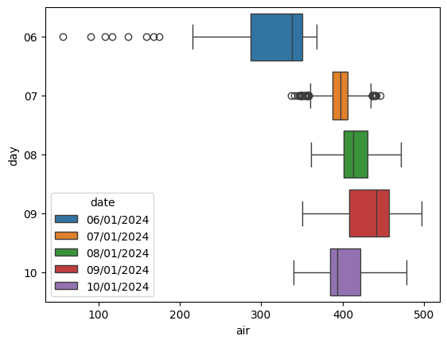

```python
#Cajas de Calidad de aire por dias
sns.boxplot (
    data=dataframe,
    x='air',
    y='day',
    hue='date',
)
```

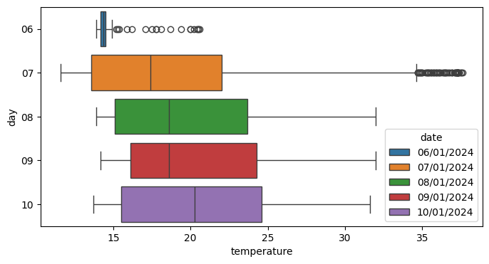

```python
#Cajas de Temperatura por dias
plt.figure(figsize=(8,4))
sns.boxplot (
    data=dataframe,
    x='temperature',
    y='day',
    hue='date',
)
```

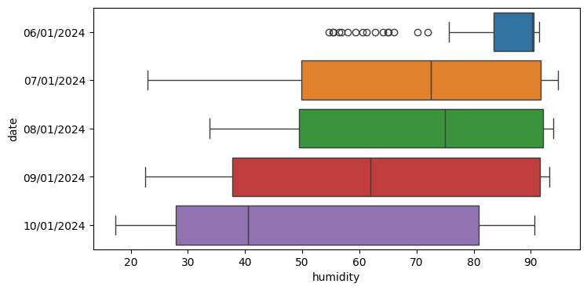

```python
#Cajas de Humedad por dias
plt.figure(figsize=(8,4))
sns.boxplot (
    data=dataframe,
    x='humidity',
    y='date',
    hue='date',
)
```

Se presume que el primer dia los sensores se estaban precalentando y calibrando

**Tambien corregimos la conversión datatime con zona horaria Lima**

```python
dia1=dataframe['date']=='06/01/2024'
dia2=dataframe['date']=='07/01/2024'
```

```python
dataframe.drop(dataframe.loc[dia1].index, inplace=True)
```

```python
print(f'Shape del dataframe original: {dataframepre.shape}')
print(f'Shape del dataframe sin outliers: {dataframe.shape}')
print(f'Cantidad de registros eliminados del dia 1 y 2: {dataframepre.shape[0]-dataframe.shape[0]}')
```

[output not shown]

## Volvemos a graficar los boxplots por dias

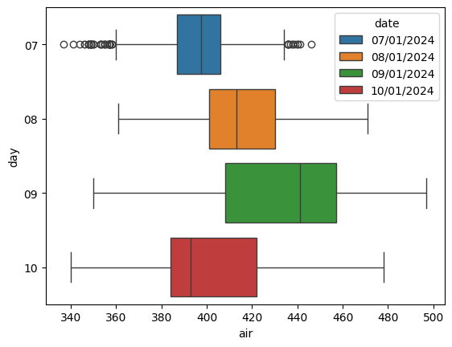

```python
#Cajas de Calidad de aire por dias
sns.boxplot (
    data=dataframe,
    x='air',
    y='day',
    hue='date',
)
```

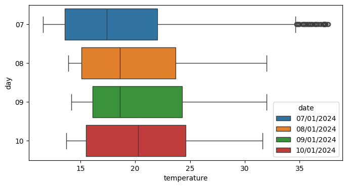

```python
#Cajas de Temperatura por dias
plt.figure(figsize=(8,4))
sns.boxplot (
    data=dataframe,
    x='temperature',
    y='day',
    hue='date',
)
```

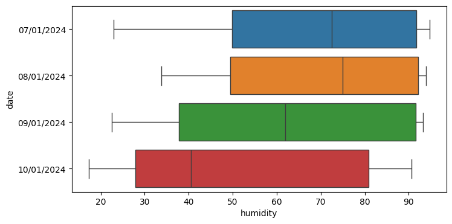

```python
#Cajas de Humedad por dias
plt.figure(figsize=(8,4))
sns.boxplot (
    data=dataframe,
    x='humidity',
    y='date',
    hue='date',
)
```

# 3. Analsis bivariado

## Calidad de aire y temperatura

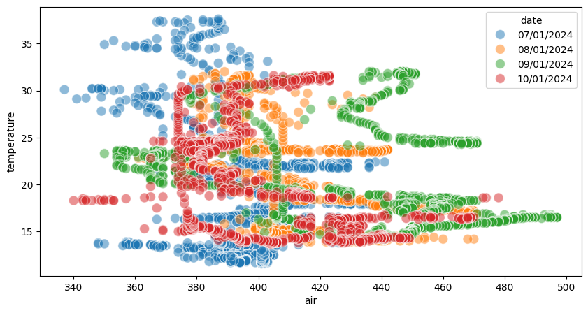

```python
#Grafica de puntos (Scatterplot)
plt.figure(figsize=(10,5))
sns.scatterplot(
    data=dataframe,
    x='air',
    y='temperature',
    hue='date',
    alpha=0.5,
    s=100
);
```

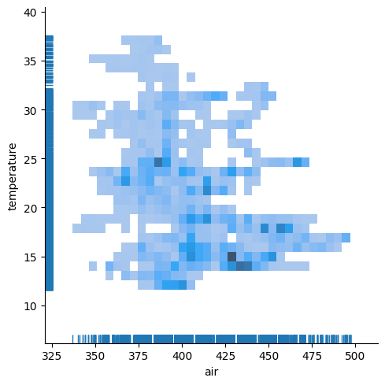

```python
#Histograma 2D, nos muestra la cantidad de valores dentro de x - y
sns.displot(
    data=dataframe,
    x='air',
    y='temperature',
    rug=True,
);
```

- Se puede apreciar que la temperatura entre 12 - 33 y la calidad de aire entre 330 - 490 es mas frecuente

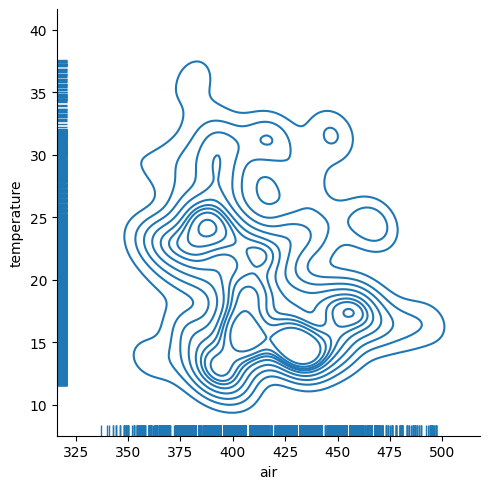

```python
#Grafico de densidades: para apreciar donde se acumulan los datos con mayor densidad
#Se visualizan los focos de densidad: En este caso 3 focos con mayor densidad y 3 con menor densidad
sns.displot(
    data=dataframe,
    x='air',
    y='temperature',
    rug=True,
    kind='kde',
    #hue='date'
);
```

## Calidad de aire y humedad

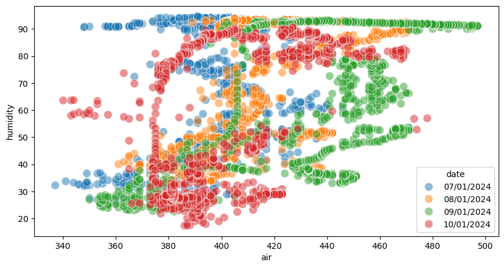

```python
#Grafica de puntos (Scatterplot)
plt.figure(figsize=(10,5))
sns.scatterplot(
    data=dataframe,
    x='air',
    y='humidity',
    hue='date',
    alpha=0.5,
    s=100
);
```

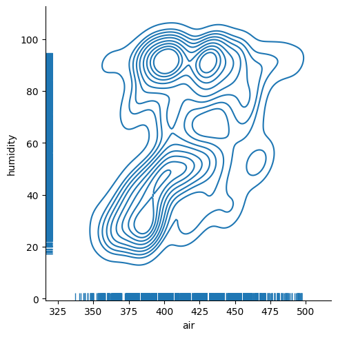

```python
#Grafico de densidades: para apreciar donde se acumulan los datos con mayor densidad
#Se visualizan los focos de densidad: En este caso 3 focos con mayor densidad y 3 con menor densidad
sns.displot(
    data=dataframe,
    x='air',
    y='humidity',
    rug=True,
    kind='kde',
    #hue='date'
);
```

## Temperatura y humedad

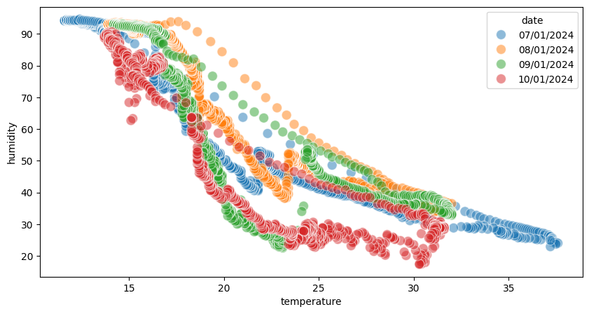

```python
#Grafica de puntos (Scatterplot)
plt.figure(figsize=(10,5))
sns.scatterplot(
    data=dataframe,
    x='temperature',
    y='humidity',
    hue='date',
    alpha=0.5,
    s=100
);
```

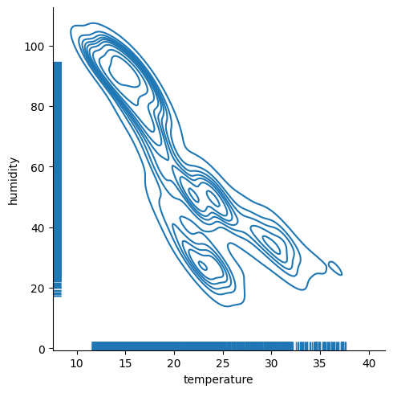

```python
#Grafico de densidades: para apreciar donde se acumulan los datos con mayor densidad
#Se visualizan los focos de densidad: En este caso 3 focos con mayor densidad y 3 con menor densidad
sns.displot(
    data=dataframe,
    x='temperature',
    y='humidity',
    rug=True,
    kind='kde',
    #hue='date'
);
```

## Estableciendo relaciones

### Correlación: Cuando dos variables parecen estar relacionadas

Temperatura y humedad parecen estar relacionadas

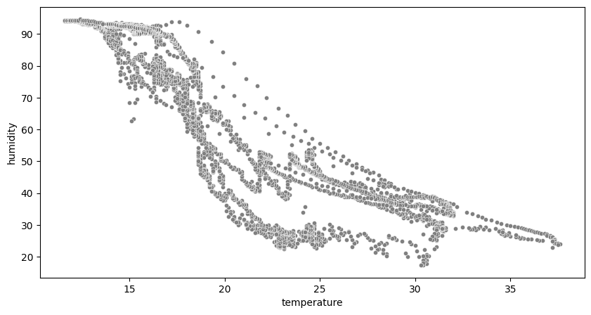

```python
plt.figure(figsize=(10,5))
sns.scatterplot(
    data=dataframe,
    x='temperature',
    y='humidity',
    color='gray',
    s=20
);
```

### Matriz de correlación lineal

```python
dataframe.corr(numeric_only=True)
```

|  | air | humidity | temperature |
| --- | --- | --- | --- |
| air | 1.000000 | 0.415092 | -0.234078 |
| humidity | 0.415092 | 1.000000 | -0.882599 |
| temperature | -0.234078 | -0.882599 | 1.000000 |

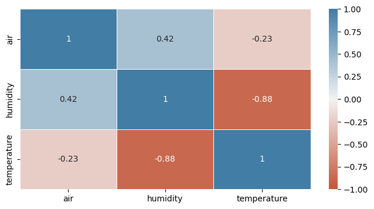

```python
#Visualizando los los coeficientes de correlación
plt.figure(figsize=(8,4))
sns.heatmap(
    data=dataframe.corr(numeric_only=True),
    cmap=sns.diverging_palette(20,238, as_cmap=True),
    center=0,
    vmin=-1,
    vmax=1,
    linewidth=.5,
    annot=True,
)
```

- Podemos apreciar que existe una correlación lineal negativa entre Temperatura y humedad
- 0: asociación nula.
- 0.1: asociación pequeña.
- 0.3: asociación mediana.
- 0.5: asociación moderada.
- 0.7: asociación alta.
- 0.9: asociación muy alta.

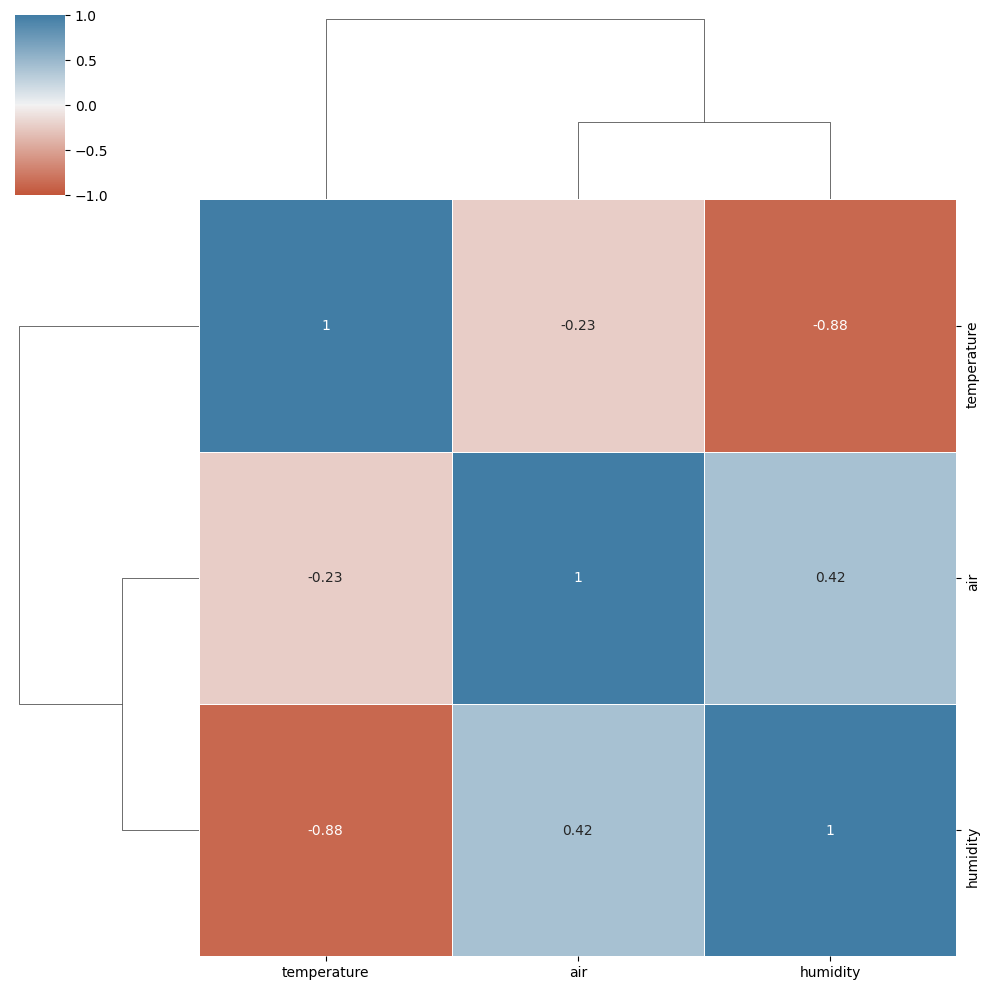

```python
#Clustermap: Permite ordenando los resultados
plt.figure(figsize=(8,4))
sns.clustermap(
    data=dataframe.corr(numeric_only=True),
    cmap=sns.diverging_palette(20,238, as_cmap=True),
    center=0,
    vmin=-1,
    vmax=1,
    linewidth=.5,
    annot=True,
)
```

### Análisis de regresión simple: fuerza del efecto

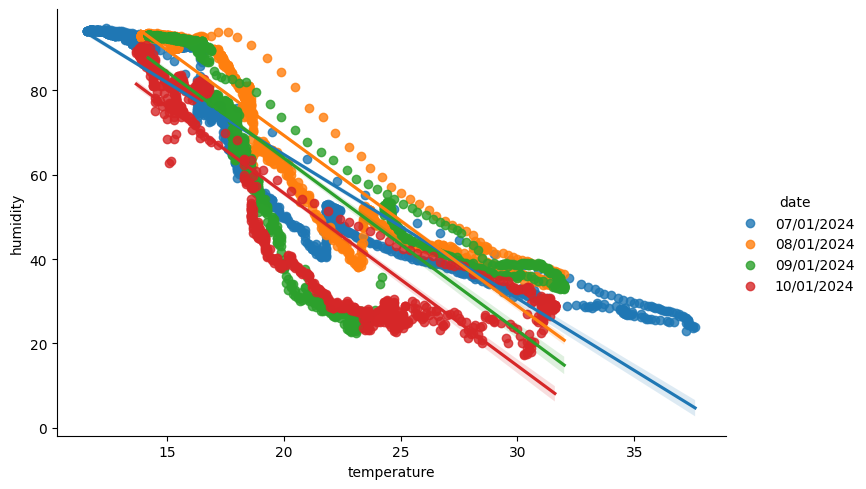

```python
sns.lmplot(
    data=dataframe,
    x='temperature',
    y='humidity',
    hue='date',
    aspect=1.5
)
```

# 4. Regresión lineal

```python
from sklearn import linear_model
from sklearn.metrics import mean_squared_error, r2_score
from sklearn.model_selection import train_test_split
x = dataframe.loc[:,['temperature']].values
y = dataframe.loc[:,['humidity']].values
```

```python
#X e y son tus características y etiquetas, respectivamente, La proporción de división es 1/3 para el conjunto de prueba y 2/3 para el conjunto de entrenamiento
x_train,x_test,y_train,y_test=train_test_split(x,y,test_size=0.2,random_state = 0)
```

```python
regressor=linear_model.LinearRegression() # Crea una instancia del modelo de Regresión Lineal
regressor.fit(x_train, y_train) # Ajusta el modelo a los datos de entrenamiento
```

```
LinearRegression()
```

```python
y_pred=regressor.predict(x_test) #predicciones basadas en un conjunto de características dado (X_test)
```

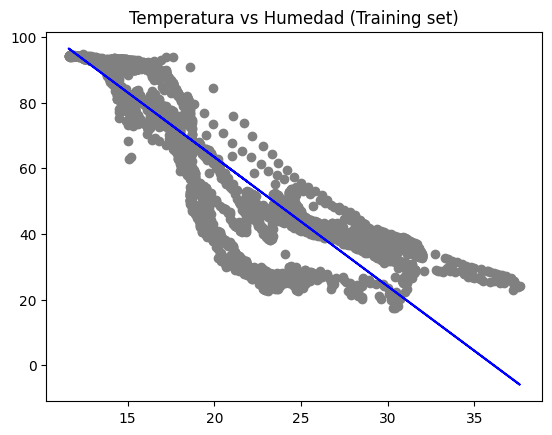

```python
plt.scatter(x_train, y_train, color = 'gray') #puntos
plt.plot(x_train, regressor.predict(x_train), color = 'blue') #linea
plt.title('Temperatura vs Humedad (Training set)')
plt.show()
```

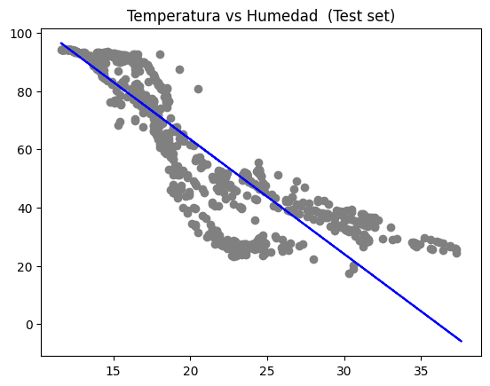

```python
plt.scatter(x_test, y_test, color = 'gray')
plt.plot(x_train, regressor.predict(x_train), color = 'blue')
plt.title('Temperatura vs Humedad  (Test set)')
plt.show()
```

## Metricas

```python
y_pred=regressor.predict(x_train)
#ecuación de la recta y = mX + b nuestra pendiente “m” es el coeficiente
print(f'Coefficients: {regressor.coef_}')
#el término independiente “b”
print(f'Independent term: {regressor.intercept_}')
#Error Cuadrado Medio RMSE: compara un valor predicho y un valor observado o conocido.
#los valores tiene que ser bajos con respecto a otros modelos
print(f'Mean squared error (RMSE): {mean_squared_error(y_train,y_pred)}')
#r2:debe ser cercano a 1 ajuste perfecto
print(f'R2 score: {r2_score(y_train,y_pred)}')
```

```
Coefficients: [[-3.93565856]]
Independent term: [142.12781966]
Mean squared error (RMSE): 136.3485594150254
R2 score: 0.7801065745935634
```

- Podemos concluir que el valor de R2 es bueno para realizar predicciones

### Probamos la predicción

```python
#¿Cuanto sera la humedad con una temperatura de 22 grados?
temperatura1=10
prediction1=regressor.predict([[temperatura1]])
print(f'RSTA: Para una temperatura de: {temperatura1}°C, la humedad es de: {prediction1}%' )
```

```
RSTA: Para una temperatura de: 10°C, la humedad es de: [[102.77123408]]%
```

De acuerdo con los especialistas, la humedad relativa del aire en una habitación no debería estar por encima de 40% y no superar el 60%. Un exceso produce:

- Síntomas de tipo alérgico: aumentar la cantidad de moco en la nariz y la garganta, causando congestión, estornudos, secreción nasal y goteo posnasal
- Dermatitis inflamada, eccema y asma

# 5. Clusterización

## K-Means

es uno de los más usados para encontrar grupos ocultos, o sospechados en teoría sobre un conjunto de datos no etiquetado.

```python
from sklearn.cluster import KMeans
from sklearn.preprocessing import MinMaxScaler
from sklearn.metrics import pairwise_distances_argmin_min
from mpl_toolkits.mplot3d import Axes3D
from scipy.spatial.distance import cdist
from sklearn.metrics import silhouette_score
from sklearn import metrics
plt.rcParams['figure.figsize'] = (16, 9)
plt.style.use('ggplot')
```

```python
x = np.array(dataframe[["temperature","humidity","air"]])
y = np.array(dataframe['hour'])
x.shape
```

```
(5246, 3)
```

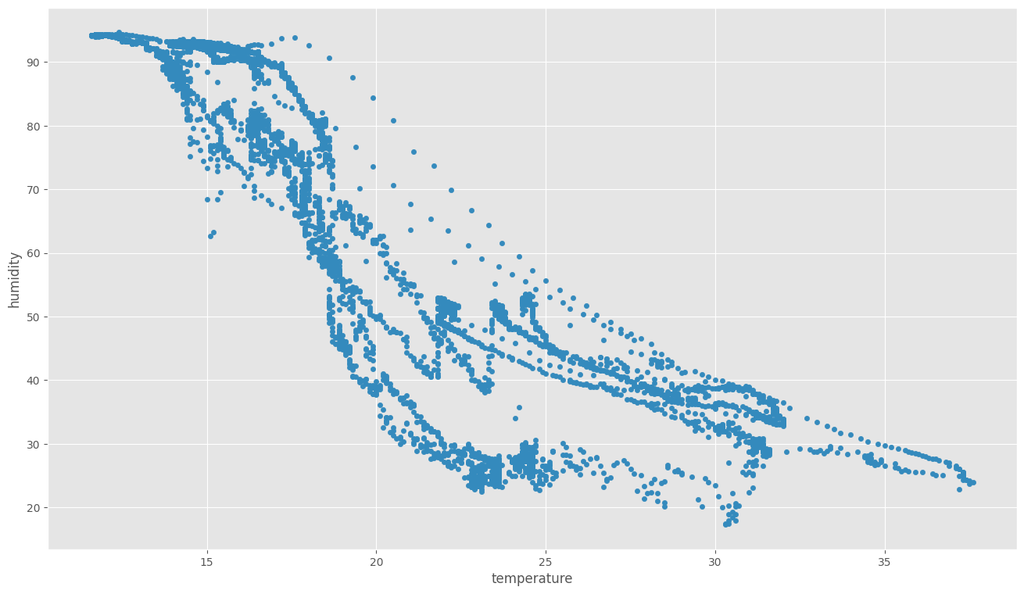

```python
dataframe.plot(
    kind='scatter',
    x='temperature',
    y='humidity'
);
```

### Obtener el valor K

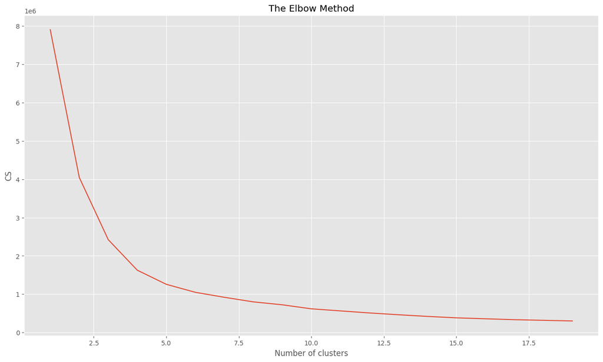

```python
cs = []
for i in range(1, 20):
    kmeans = KMeans(n_clusters = i, init = 'k-means++', max_iter = 300, n_init = 10, random_state = 0)
    kmeans.fit(x)
    cs.append(kmeans.inertia_)
plt.plot(range(1, 20), cs)
plt.title('The Elbow Method')
plt.xlabel('Number of clusters')
plt.ylabel('CS')
plt.show()
```

```python
silhouette_coefficients = []
n_clusters = []

for i in range(2, 10):
    kmeans = KMeans(n_clusters=i, n_init=10).fit(x)
    n_clusters.append(i)
    r = silhouette_score(x, kmeans.labels_)
    silhouette_coefficients.append(r)
```

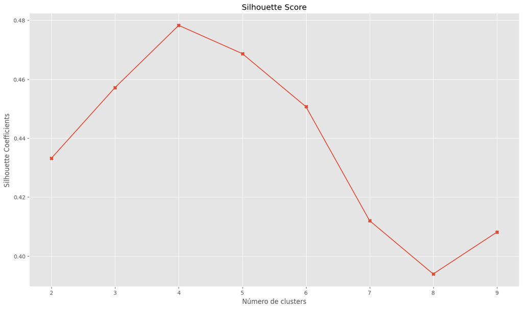

```python
plt.plot(n_clusters, silhouette_coefficients, marker="X");
plt.xlabel("Número de clusters")
plt.ylabel("Silhouette Coefficients")
plt.title("Silhouette Score");
```

### Ejecutamos K-Means para 4 clusters

```python
kmeans = KMeans(n_clusters=4).fit(x)
centroids = kmeans.cluster_centers_
print(centroids)
```

```
[[ 23.89174631  47.35256299 418.93136403]
 [ 16.60693001  82.82619543 447.53915454]
 [ 25.41696035  33.60624082 381.34508076]
 [ 14.9179845   86.93449612 398.21860465]]
```

```python
y_kmeans=kmeans.predict(x)
accuracy=metrics.adjusted_rand_score(y, y_kmeans)
print(accuracy)
```

```
0.08925507289917387
```

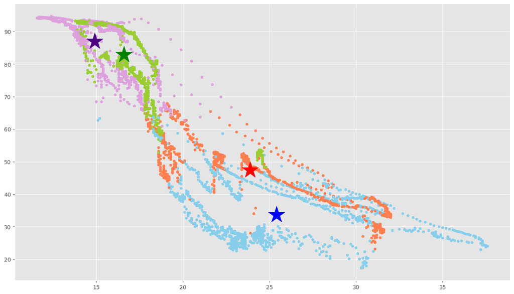

```python
# Getting the values and plotting it
labels = kmeans.predict(x)
C = kmeans.cluster_centers_
colores1=['red','green','blue','indigo']
colores2=['coral','yellowgreen','skyblue','plum']
asignar=[]
for row in labels:
    asignar.append(colores2[row])
f1 = dataframe.temperature.values
f2 = dataframe.humidity.values

plt.scatter(f1, f2, c=asignar, s=20)
plt.scatter(C[:, 0], C[:, 1], marker='*', c=colores1, s=1000)
plt.show()
```

```python
# Observaciones por cada uno de los clusters
copy =  pd.DataFrame()
copy['temperature']=dataframe['temperature'].values
copy['humidity']=dataframe['humidity'].values
copy['label'] = labels;
cantidadGrupo =  pd.DataFrame()
cantidadGrupo['color']=colores1
cantidadGrupo['cantidad']=copy.groupby('label').size()
cantidadGrupo
```

|  | color | cantidad |
| --- | --- | --- |
| 0 | red | 1151 |
| 1 | green | 1443 |
| 2 | blue | 1362 |
| 3 | indigo | 1290 |

```python
#vemos el representante del grupo, el usuario cercano a su centroid
closest, _ = pairwise_distances_argmin_min(kmeans.cluster_centers_, x)
closest
#nos muestra la posición dela observación en el array
```

```
array([ 966, 2632, 4925, 4375], dtype=int64)
```

```python
hours=dataframe.hour.values
for row in closest:
    print(hours[row])
#Se muestran la hora que representa a cada centroide
```

```
16
22
14
05
```

### Clasificar nuevas muestras

```python
#[temperature,humidity,air]
x_new = np.array([[15,60,200]])
new_labels = kmeans.predict(x_new)
print(new_labels)
```

```
[2]
```

### ES TODO POR LE MOMENTO, MUCHAS GRACIAS 👋✨🙌🎉